# Act Report

## Introduction

The '@Weratedogs' is a twitter account that rates pretty dogs from all around the world by a denominator of 10. By accessing the twitter API we can load an interesting amount of informations about each tweet in @WeRateDogs. The whole data contain API data combined with informations about dogs breed obtained by a neural network on dogs images and archive. This large amount of data can be wrangling by assesing and cleaning to finally search for insights about data and interesting features relations.

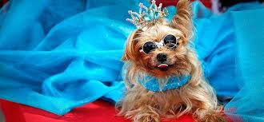

The cleaned merged dataset contains 840 rows of data about dogs and 23 columns name, retweet and favorite counts, ratings etc.

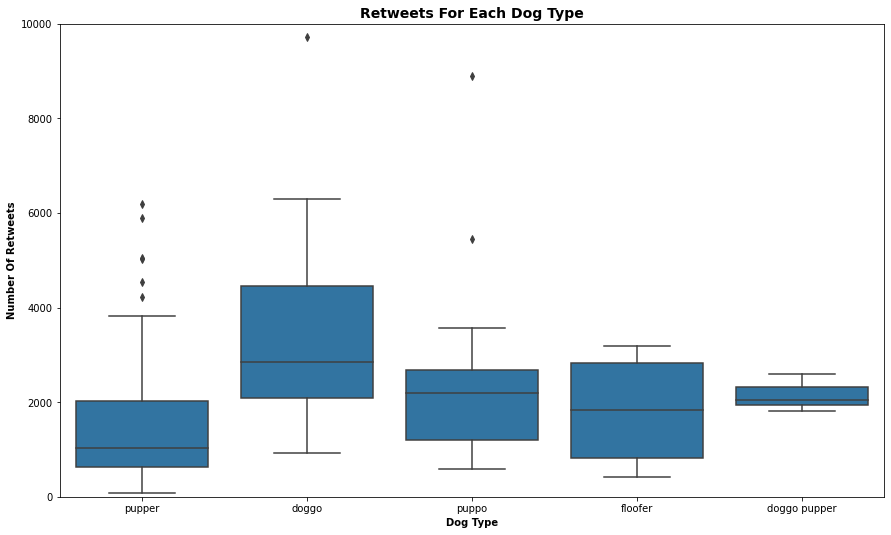

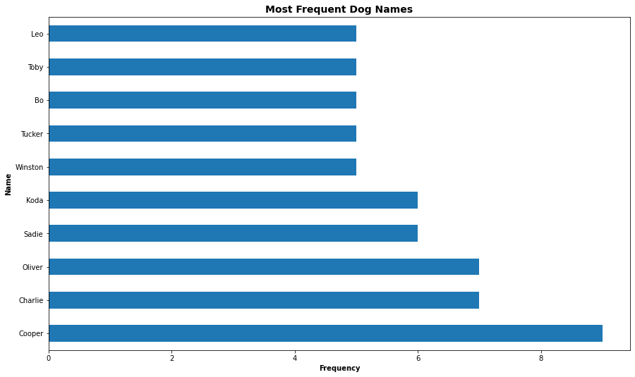

- 'pupper' dogs are the most frequent dogs in the @WeRateDogs but they have the lowest number of retweets and favorites in term of count.
- All dogs in @WeRateDogs twitter account have a interesting rating numerator, however, 'pupper' dogs have the highest numerator rating, and it is larger than 10 for the majority of dogs some of them achieved 27 as a rating numerator.

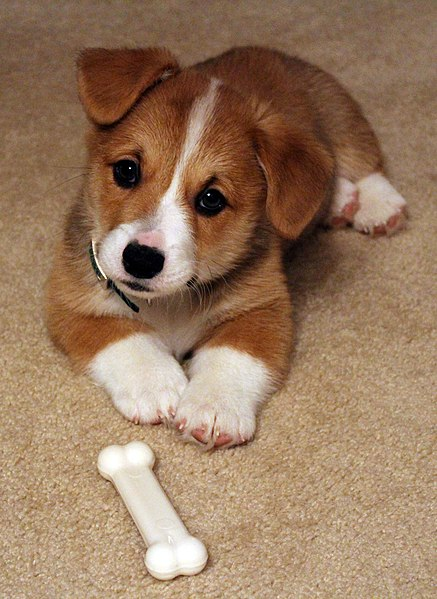